# Instacart Market Basket Analysis

## Importing the required libraries

```python
# Import the libraries you'll need for this analysis
import pandas as pd
import matplotlib.pyplot as plt
```

```python
# Load the datasets
# Note: These files use semicolon (;) as the separator instead of comma
orders         = pd.read_csv('/datasets/instacart_orders.csv', sep=';')
products       = pd.read_csv('/datasets/products.csv', sep=';')
departments    = pd.read_csv('/datasets/departments.csv', sep=';')
aisles         = pd.read_csv('/datasets/aisles.csv', sep=';')
order_products = pd.read_csv('/datasets/order_products.csv', sep=';')
```

## Analyze your data

In the cells below, display the datasets using `.info()` and `.head()` to gain insights into their structure and content.

```python
# In this cell, type "orders" below this line and execute the cell
display(orders)
orders.info()
orders.head()
```

|  | order_id | user_id | order_number | order_dow | order_hour_of_day | days_since_prior_order |
| --- | --- | --- | --- | --- | --- | --- |
| 0 | 1515936 | 183418 | 11 | 6 | 13 | 30.0 |
| 1 | 1690866 | 163593 | 5 | 5 | 12 | 9.0 |
| 2 | 1454967 | 39980 | 4 | 5 | 19 | 2.0 |
| 3 | 1768857 | 82516 | 56 | 0 | 20 | 10.0 |
| 4 | 3007858 | 196724 | 2 | 4 | 12 | 17.0 |
| ... | ... | ... | ... | ... | ... | ... |
| 478962 | 3210681 | 5617 | 5 | 1 | 14 | 7.0 |
| 478963 | 3270802 | 112087 | 2 | 3 | 13 | 6.0 |
| 478964 | 885349 | 82944 | 16 | 2 | 11 | 6.0 |
| 478965 | 216274 | 4391 | 3 | 3 | 8 | 8.0 |
| 478966 | 2071924 | 1730 | 18 | 1 | 14 | 15.0 |

478967 rows × 6 columns

```
<class 'pandas.core.frame.DataFrame'>
RangeIndex: 478967 entries, 0 to 478966
Data columns (total 6 columns):
 #   Column                  Non-Null Count   Dtype
---  ------                  --------------   -----
 0   order_id                478967 non-null  int64
 1   user_id                 478967 non-null  int64
 2   order_number            478967 non-null  int64
 3   order_dow               478967 non-null  int64
 4   order_hour_of_day       478967 non-null  int64
 5   days_since_prior_order  450148 non-null  float64
dtypes: float64(1), int64(5)
memory usage: 21.9 MB
```

|  | order_id | user_id | order_number | order_dow | order_hour_of_day | days_since_prior_order |
| --- | --- | --- | --- | --- | --- | --- |
| 0 | 1515936 | 183418 | 11 | 6 | 13 | 30.0 |
| 1 | 1690866 | 163593 | 5 | 5 | 12 | 9.0 |
| 2 | 1454967 | 39980 | 4 | 5 | 19 | 2.0 |
| 3 | 1768857 | 82516 | 56 | 0 | 20 | 10.0 |
| 4 | 3007858 | 196724 | 2 | 4 | 12 | 17.0 |

```python
# In this cell, type "products" below this line and execute the cell
products
products.info()
products.head()
```

```
<class 'pandas.core.frame.DataFrame'>
RangeIndex: 49694 entries, 0 to 49693
Data columns (total 4 columns):
 #   Column         Non-Null Count  Dtype
---  ------         --------------  -----
 0   product_id     49694 non-null  int64
 1   product_name   48436 non-null  object
 2   aisle_id       49694 non-null  int64
 3   department_id  49694 non-null  int64
dtypes: int64(3), object(1)
memory usage: 1.5+ MB
```

|  | product_id | product_name | aisle_id | department_id |
| --- | --- | --- | --- | --- |
| 0 | 1 | Chocolate Sandwich Cookies | 61 | 19 |
| 1 | 2 | All-Seasons Salt | 104 | 13 |
| 2 | 3 | Robust Golden Unsweetened Oolong Tea | 94 | 7 |
| 3 | 4 | Smart Ones Classic Favorites Mini Rigatoni Wit... | 38 | 1 |
| 4 | 5 | Green Chile Anytime Sauce | 5 | 13 |

Repeat this process for each dataset to understand the structure, including the types of columns and rows they contain. Add additional code cells as needed for your analysis.

```python
display(departments)
departments.info()
departments.head()
```

|  | department_id | department |
| --- | --- | --- |
| 0 | 1 | frozen |
| 1 | 2 | other |
| 2 | 3 | bakery |
| 3 | 4 | produce |
| 4 | 5 | alcohol |
| 5 | 6 | international |
| 6 | 7 | beverages |
| 7 | 8 | pets |
| 8 | 9 | dry goods pasta |
| 9 | 10 | bulk |
| 10 | 11 | personal care |
| 11 | 12 | meat seafood |
| 12 | 13 | pantry |
| 13 | 14 | breakfast |
| 14 | 15 | canned goods |
| 15 | 16 | dairy eggs |
| 16 | 17 | household |
| 17 | 18 | babies |
| 18 | 19 | snacks |
| 19 | 20 | deli |
| 20 | 21 | missing |

```
<class 'pandas.core.frame.DataFrame'>
RangeIndex: 21 entries, 0 to 20
Data columns (total 2 columns):
 #   Column         Non-Null Count  Dtype
---  ------         --------------  -----
 0   department_id  21 non-null     int64
 1   department     21 non-null     object
dtypes: int64(1), object(1)
memory usage: 464.0+ bytes
```

|  | department_id | department |
| --- | --- | --- |
| 0 | 1 | frozen |
| 1 | 2 | other |
| 2 | 3 | bakery |
| 3 | 4 | produce |
| 4 | 5 | alcohol |

```python
display(aisles)
aisles.info()
aisles.head()
```

|  | aisle_id | aisle |
| --- | --- | --- |
| 0 | 1 | prepared soups salads |
| 1 | 2 | specialty cheeses |
| 2 | 3 | energy granola bars |
| 3 | 4 | instant foods |
| 4 | 5 | marinades meat preparation |
| ... | ... | ... |
| 129 | 130 | hot cereal pancake mixes |
| 130 | 131 | dry pasta |
| 131 | 132 | beauty |
| 132 | 133 | muscles joints pain relief |
| 133 | 134 | specialty wines champagnes |

134 rows × 2 columns

```
<class 'pandas.core.frame.DataFrame'>
RangeIndex: 134 entries, 0 to 133
Data columns (total 2 columns):
 #   Column    Non-Null Count  Dtype
---  ------    --------------  -----
 0   aisle_id  134 non-null    int64
 1   aisle     134 non-null    object
dtypes: int64(1), object(1)
memory usage: 2.2+ KB
```

|  | aisle_id | aisle |
| --- | --- | --- |
| 0 | 1 | prepared soups salads |
| 1 | 2 | specialty cheeses |
| 2 | 3 | energy granola bars |
| 3 | 4 | instant foods |
| 4 | 5 | marinades meat preparation |

```python
display(order_products)
order_products.info(show_counts= True)
order_products.head()
```

|  | order_id | product_id | add_to_cart_order | reordered |
| --- | --- | --- | --- | --- |
| 0 | 2141543 | 11440 | 17.0 | 0 |
| 1 | 567889 | 1560 | 1.0 | 1 |
| 2 | 2261212 | 26683 | 1.0 | 1 |
| 3 | 491251 | 8670 | 35.0 | 1 |
| 4 | 2571142 | 1940 | 5.0 | 1 |
| ... | ... | ... | ... | ... |
| 4545002 | 577211 | 15290 | 12.0 | 1 |
| 4545003 | 1219554 | 21914 | 9.0 | 0 |
| 4545004 | 692640 | 47766 | 4.0 | 1 |
| 4545005 | 319435 | 691 | 8.0 | 1 |
| 4545006 | 1398151 | 28733 | 9.0 | 0 |

4545007 rows × 4 columns

```
<class 'pandas.core.frame.DataFrame'>
RangeIndex: 4545007 entries, 0 to 4545006
Data columns (total 4 columns):
 #   Column             Non-Null Count    Dtype
---  ------             --------------    -----
 0   order_id           4545007 non-null  int64
 1   product_id         4545007 non-null  int64
 2   add_to_cart_order  4544171 non-null  float64
 3   reordered          4545007 non-null  int64
dtypes: float64(1), int64(3)
memory usage: 138.7 MB
```

|  | order_id | product_id | add_to_cart_order | reordered |
| --- | --- | --- | --- | --- |
| 0 | 2141543 | 11440 | 17.0 | 0 |
| 1 | 567889 | 1560 | 1.0 | 1 |
| 2 | 2261212 | 26683 | 1.0 | 1 |
| 3 | 491251 | 8670 | 35.0 | 1 |
| 4 | 2571142 | 1940 | 5.0 | 1 |

The orders dataset has missing values in the ‘days_since_prior_order’ column

```python
# In this cell, type "orders.info() below this line and execute the cell
orders.info()
```

```
<class 'pandas.core.frame.DataFrame'>
RangeIndex: 478967 entries, 0 to 478966
Data columns (total 6 columns):
 #   Column                  Non-Null Count   Dtype
---  ------                  --------------   -----
 0   order_id                478967 non-null  int64
 1   user_id                 478967 non-null  int64
 2   order_number            478967 non-null  int64
 3   order_dow               478967 non-null  int64
 4   order_hour_of_day       478967 non-null  int64
 5   days_since_prior_order  450148 non-null  float64
dtypes: float64(1), int64(5)
memory usage: 21.9 MB
```

```python
# In this cell, run order_products.info() below, but include the argument show_counts=True since this is a large file.
order_products.info(show_counts = True)
```

```
<class 'pandas.core.frame.DataFrame'>
RangeIndex: 4545007 entries, 0 to 4545006
Data columns (total 4 columns):
 #   Column             Non-Null Count    Dtype
---  ------             --------------    -----
 0   order_id           4545007 non-null  int64
 1   product_id         4545007 non-null  int64
 2   add_to_cart_order  4544171 non-null  float64
 3   reordered          4545007 non-null  int64
dtypes: float64(1), int64(3)
memory usage: 138.7 MB
```

Repeat the use of .info() on the remaining datasets to identify missing values and understand their structure. Check the "Non-Null Count" for each dataset to spot any columns with missing values.

### Missing Values Summary

The **`orders`** dataset has missing values in the `days_since_prior_order` column (28,819).

The **`products`** dataset has missing values in the `product_name` column (1,258).

The **`departments`** dataset has no missing values.

The **`aisles`** dataset has no missing values.

The **`order_products`** dataset has has missing values in the `add_to_cart_order` column (836).

## Find and Remove Missing Values

We noticed that some columns contain missing values.

Here are some useful code snippets:

```
# Identify missing values in each column
print(dataset.isnull().sum())

# Display rows where a specific column has missing values
print(dataset[dataset['column_name'].isna()])

# Confirm no missing values remain
print(dataset.isnull().sum())
```

### `products` Data Frame

We will begin by addressing the missing values in the `products` data frame.

```python
# Display rows where the product_name column has missing values
display(products[products['product_name'].isna()])
```

|  | product_id | product_name | aisle_id | department_id |
| --- | --- | --- | --- | --- |
| 37 | 38 | NaN | 100 | 21 |
| 71 | 72 | NaN | 100 | 21 |
| 109 | 110 | NaN | 100 | 21 |
| 296 | 297 | NaN | 100 | 21 |
| 416 | 417 | NaN | 100 | 21 |
| ... | ... | ... | ... | ... |
| 49552 | 49553 | NaN | 100 | 21 |
| 49574 | 49575 | NaN | 100 | 21 |
| 49640 | 49641 | NaN | 100 | 21 |
| 49663 | 49664 | NaN | 100 | 21 |
| 49668 | 49669 | NaN | 100 | 21 |

1258 rows × 4 columns

It seems suspicious that all rows with missing `product_name` might be associated with `aisle_id` 100 and `department_id` 21. Let’s verify this by checking if any rows with missing `product_name` have an `aisle_id` different from 100 and 21. This will help us confirm if the issue is isolated to this aisle or spread across others.

```python
#Combining conditions to see if aile_id and department_id match the number of missing values in product_name
print(products[(products['aisle_id'] == 100) & (products['department_id'] == 21) & (products['product_name'].isna())])
```

```
       product_id product_name  aisle_id  department_id
37             38          NaN       100             21
71             72          NaN       100             21
109           110          NaN       100             21
296           297          NaN       100             21
416           417          NaN       100             21
...           ...          ...       ...            ...
49552       49553          NaN       100             21
49574       49575          NaN       100             21
49640       49641          NaN       100             21
49663       49664          NaN       100             21
49668       49669          NaN       100             21

[1258 rows x 4 columns]
```

This combination appears to have the same number of missing values that only `product_name` had; this tells us that when `product_name` is **NaN** that both `aisle_id` **AND** `department_id` are 100 and 21, respectively.

```python
# Combine conditions to check for missing product names in aisles other than 100
display(products[(products['product_name'].isna()) & ~(products['aisle_id'] == 100)])
```

|  | product_id | product_name | aisle_id | department_id |
| --- | --- | --- | --- | --- |

```python
# Combine conditions to check for missing product names in aisles other than 21
display(products[(products['product_name'].isna()) & ~(products['department_id'] == 21)])
```

|  | product_id | product_name | aisle_id | department_id |
| --- | --- | --- | --- | --- |

As stated previously, when `product_name` is **NaN** `aisle_id` and `department_id` are 100 and 21.

To better understand the missing product_name values, let’s determine what department_id 21 and aisle_id 100 represent by referencing the departments and aisles tables.

```python
# What is this aisle and department?
display(products[['product_name','aisle_id', 'department_id']].head(20))
```

|  | product_name | aisle_id | department_id |
| --- | --- | --- | --- |
| 0 | Chocolate Sandwich Cookies | 61 | 19 |
| 1 | All-Seasons Salt | 104 | 13 |
| 2 | Robust Golden Unsweetened Oolong Tea | 94 | 7 |
| 3 | Smart Ones Classic Favorites Mini Rigatoni Wit... | 38 | 1 |
| 4 | Green Chile Anytime Sauce | 5 | 13 |
| 5 | Dry Nose Oil | 11 | 11 |
| 6 | Pure Coconut Water With Orange | 98 | 7 |
| 7 | Cut Russet Potatoes Steam N' Mash | 116 | 1 |
| 8 | Light Strawberry Blueberry Yogurt | 120 | 16 |
| 9 | Sparkling Orange Juice & Prickly Pear Beverage | 115 | 7 |
| 10 | Peach Mango Juice | 31 | 7 |
| 11 | Chocolate Fudge Layer Cake | 119 | 1 |
| 12 | Saline Nasal Mist | 11 | 11 |
| 13 | Fresh Scent Dishwasher Cleaner | 74 | 17 |
| 14 | Overnight Diapers Size 6 | 56 | 18 |
| 15 | Mint Chocolate Flavored Syrup | 103 | 19 |
| 16 | Rendered Duck Fat | 35 | 12 |
| 17 | Pizza for One Suprema Frozen Pizza | 79 | 1 |
| 18 | Gluten Free Quinoa Three Cheese & Mushroom Blend | 63 | 9 |
| 19 | Pomegranate Cranberry & Aloe Vera Enrich Drink | 98 | 7 |

```python
# Fill missing product names with 'Unknown'
products['product_name'] = products['product_name'].fillna(value="Unknown")

#Checked to see if it worked
display(products.sample(20, random_state=150))
```

|  | product_id | product_name | aisle_id | department_id |
| --- | --- | --- | --- | --- |
| 20284 | 20285 | Non Dairy Choc Fudge Brownie | 37 | 1 |
| 41959 | 41960 | Organic Daikon Root- Bunch | 83 | 4 |
| 28228 | 28229 | Sweet Cream Style Corn | 81 | 15 |
| 46789 | 46790 | Method 10oz foaming hand wash juicy pear | 127 | 11 |
| 49146 | 49147 | Fabric & Upholstery Protector | 114 | 17 |
| 30021 | 30022 | Organic Chunky Tomato & Herb Pasta Sauce | 9 | 9 |
| 9117 | 9118 | Four Cheese Microwavable Mashed Potatoes | 4 | 9 |
| 13232 | 13233 | Unknown | 100 | 21 |
| 27053 | 27054 | Adult Liquid Cough Suppressant Medicine Grape ... | 11 | 11 |
| 2399 | 2400 | 100% Pure Evening Primrose Oil | 47 | 11 |
| 25700 | 25701 | Unknown | 100 | 21 |
| 30667 | 30668 | Half Baked Frozen Yogurt | 37 | 1 |
| 13553 | 13554 | Organic Gluten Free Dude Ranch Multigrain Snac... | 107 | 19 |
| 24553 | 24554 | Bars- Slim- Raspberry Truffle- Vegan- Bars- Gl... | 65 | 11 |
| 4902 | 4903 | 2 In 1 Ocean Lift Dandruff Shampoo + Conditioner | 22 | 11 |
| 34397 | 34398 | Natural M&C Four Cheese | 4 | 9 |
| 29865 | 29866 | Original inka Corn | 107 | 19 |
| 20744 | 20745 | Ultra Moisture Coconut Oasis Body Wash | 127 | 11 |
| 9185 | 9186 | Culinary Coconut Milk | 91 | 16 |
| 48844 | 48845 | Roasted Brussels Sprouts | 13 | 20 |

### `orders` data frame

Now let's fill in missing values from the `orders` table.

```python
# Display rows where the days_since_prior_order column has missing values
display(orders[orders['days_since_prior_order'].isna()])

#Confirming the number of NaN matches
display(orders.isnull().sum())
```

|  | order_id | user_id | order_number | order_dow | order_hour_of_day | days_since_prior_order |
| --- | --- | --- | --- | --- | --- | --- |
| 28 | 133707 | 182261 | 1 | 3 | 10 | NaN |
| 96 | 787445 | 25685 | 1 | 6 | 18 | NaN |
| 100 | 294410 | 111449 | 1 | 0 | 19 | NaN |
| 103 | 2869915 | 123958 | 1 | 4 | 16 | NaN |
| 104 | 2521921 | 42286 | 1 | 3 | 18 | NaN |
| ... | ... | ... | ... | ... | ... | ... |
| 478895 | 2589657 | 205028 | 1 | 0 | 16 | NaN |
| 478896 | 2222353 | 141211 | 1 | 2 | 13 | NaN |
| 478922 | 2272807 | 204154 | 1 | 1 | 15 | NaN |
| 478926 | 2499542 | 68810 | 1 | 4 | 19 | NaN |
| 478945 | 1387033 | 22496 | 1 | 5 | 14 | NaN |

28819 rows × 6 columns

```
order_id                      0
user_id                       0
order_number                  0
order_dow                     0
order_hour_of_day             0
days_since_prior_order    28819
dtype: int64
```

```python
# Are there any missing values where it's not a customer's first order?
display(orders[(orders['order_number'] == 1) & (orders['days_since_prior_order'].isna())])
```

|  | order_id | user_id | order_number | order_dow | order_hour_of_day | days_since_prior_order |
| --- | --- | --- | --- | --- | --- | --- |
| 28 | 133707 | 182261 | 1 | 3 | 10 | NaN |
| 96 | 787445 | 25685 | 1 | 6 | 18 | NaN |
| 100 | 294410 | 111449 | 1 | 0 | 19 | NaN |
| 103 | 2869915 | 123958 | 1 | 4 | 16 | NaN |
| 104 | 2521921 | 42286 | 1 | 3 | 18 | NaN |
| ... | ... | ... | ... | ... | ... | ... |
| 478895 | 2589657 | 205028 | 1 | 0 | 16 | NaN |
| 478896 | 2222353 | 141211 | 1 | 2 | 13 | NaN |
| 478922 | 2272807 | 204154 | 1 | 1 | 15 | NaN |
| 478926 | 2499542 | 68810 | 1 | 4 | 19 | NaN |
| 478945 | 1387033 | 22496 | 1 | 5 | 14 | NaN |

28819 rows × 6 columns

All of the missing `'days_since_prior_order'` values correspond to a customer's first ever order. This makes sense because there is no prior order! We'll leave the values as `NaN` so the column can remain numeric. Also, the `NaN` values shouldn't interfere with any calculations we might do using this column.

### `order_products` data frame

Now let's fill in missing values from the order_products table.

```python
# Display rows where the add_to_cart_order column has missing values
display(order_products.isnull().sum())

display(order_products[order_products['add_to_cart_order'].isna()])
```

```
order_id               0
product_id             0
add_to_cart_order    836
reordered              0
dtype: int64
```

|  | order_id | product_id | add_to_cart_order | reordered |
| --- | --- | --- | --- | --- |
| 737 | 2449164 | 5068 | NaN | 0 |
| 9926 | 1968313 | 43867 | NaN | 0 |
| 14394 | 2926893 | 11688 | NaN | 0 |
| 16418 | 1717990 | 4142 | NaN | 0 |
| 30114 | 1959075 | 42828 | NaN | 1 |
| ... | ... | ... | ... | ... |
| 4505662 | 1800005 | 7411 | NaN | 0 |
| 4511400 | 1633337 | 260 | NaN | 0 |
| 4517562 | 404157 | 9517 | NaN | 0 |
| 4534112 | 1673227 | 17835 | NaN | 0 |
| 4535739 | 1832957 | 17949 | NaN | 1 |

836 rows × 4 columns

```python
# Use .min() and .max() to find the minimum and maximum values for this column.
display(order_products['add_to_cart_order'].min(), order_products['add_to_cart_order'].max())
```

```
1.0
```

```
64.0
```

```python
# Save all order IDs with at least one missing value in 'add_to_cart_order'
order_id_with_missing_add_to_cart = order_products[order_products['add_to_cart_order'].isna()]['order_id'].unique()

display(order_id_with_missing_add_to_cart)

display(f"Number of orders with missing 'add_to_cart_order' values: {len(order_id_with_missing_add_to_cart)}")
```

```
array([2449164, 1968313, 2926893, 1717990, 1959075,  844733,   61355,
        936852,  264710, 1564093,  129627,  293169, 2849370, 1386261,
       3308010,  903110, 2136777, 3347453, 1888628,  165801, 2094761,
       1038146, 2997021,  813364, 2256933,  171934, 2409109, 1730767,
       1169835,  733526,  404157, 3125735,  747668, 1800005, 1961723,
        871281,  388234, 1648217, 1477139,  102236, 1021563, 1832957,
       2721963,  678116, 1220886, 1673227, 2999801, 1633337, 2470674,
       2625444, 1677118, 2479011, 3383594, 1183255, 1713430, 2652650,
       1598369, 1916118,  854647, 1302315,  888470,  180546, 2621907,
       1308785, 2729254,    9310, 2170451, 2979697, 1625713, 1529171])
```

```
"Number of orders with missing 'add_to_cart_order' values: 70"
```

```python
# Do all orders with missing values have more than 64 product

#Creates a boolean mask and a new column stating if the 'add_to_cart_order' column has a missing value or not
order_products['missing_add_to_cart_order'] = order_products['add_to_cart_order'].isna()
display(order_products['missing_add_to_cart_order'])

#Creates a table that only finds the NaN values from 'missing_add_to_cart_order' to be True
missing_true_add_to_cart_order = order_products[order_products['missing_add_to_cart_order'] == True]
display(missing_true_add_to_cart_order)

#This creates a table with our new data with only NaN values in 'add_to_cart_order' to count how many unique values occur in each column based on the 'order_id' column
table = missing_true_add_to_cart_order.groupby('order_id').count()
display(table)

#Grouped the new table with order_id against the specific column product_id in case the use is necessary for later.
table_product_only = missing_true_add_to_cart_order.groupby('order_id')['product_id'].count()
display(table_product_only)

print(table[table['product_id']> 63])
```

```
0          False
1          False
2          False
3          False
4          False
           ...
4545002    False
4545003    False
4545004    False
4545005    False
4545006    False
Name: missing_add_to_cart_order, Length: 4545007, dtype: bool
```

|  | order_id | product_id | add_to_cart_order | reordered | missing_add_to_cart_order |
| --- | --- | --- | --- | --- | --- |
| 737 | 2449164 | 5068 | NaN | 0 | True |
| 9926 | 1968313 | 43867 | NaN | 0 | True |
| 14394 | 2926893 | 11688 | NaN | 0 | True |
| 16418 | 1717990 | 4142 | NaN | 0 | True |
| 30114 | 1959075 | 42828 | NaN | 1 | True |
| ... | ... | ... | ... | ... | ... |
| 4505662 | 1800005 | 7411 | NaN | 0 | True |
| 4511400 | 1633337 | 260 | NaN | 0 | True |
| 4517562 | 404157 | 9517 | NaN | 0 | True |
| 4534112 | 1673227 | 17835 | NaN | 0 | True |
| 4535739 | 1832957 | 17949 | NaN | 1 | True |

836 rows × 5 columns

| order_id | product_id | add_to_cart_order | reordered | missing_add_to_cart_order |
| --- | --- | --- | --- | --- |
| 9310 | 1 | 0 | 1 | 1 |
| 61355 | 63 | 0 | 63 | 63 |
| 102236 | 31 | 0 | 31 | 31 |
| 129627 | 5 | 0 | 5 | 5 |
| 165801 | 6 | 0 | 6 | 6 |
| ... | ... | ... | ... | ... |
| 2999801 | 6 | 0 | 6 | 6 |
| 3125735 | 22 | 0 | 22 | 22 |
| 3308010 | 51 | 0 | 51 | 51 |
| 3347453 | 7 | 0 | 7 | 7 |
| 3383594 | 5 | 0 | 5 | 5 |

70 rows × 4 columns

```
order_id
9310        1
61355      63
102236     31
129627      5
165801      6
           ..
2999801     6
3125735    22
3308010    51
3347453     7
3383594     5
Name: product_id, Length: 70, dtype: int64
```

```
Empty DataFrame
Columns: [product_id, add_to_cart_order, reordered, missing_add_to_cart_order]
Index: []
```

```python
# Replace missing values with 999 and convert column to integer type
#Created a Series where NaN value are 999 and the column is integer data type
add_to_cart_order_series999 = order_products['add_to_cart_order'].fillna(value=999).astype('int')
display(add_to_cart_order_series999)

#input the Series created above as the new column in our DataFrame
order_products['add_to_cart_order'] = add_to_cart_order_series999

#Checked the NaN values were converted to 999
display(order_products[order_products['add_to_cart_order'] == 999])

#Checked the data type converted to integer
order_products.info()
```

```
0          17
1           1
2           1
3          35
4           5
           ..
4545002    12
4545003     9
4545004     4
4545005     8
4545006     9
Name: add_to_cart_order, Length: 4545007, dtype: int64
```

|  | order_id | product_id | add_to_cart_order | reordered | missing_add_to_cart_order |
| --- | --- | --- | --- | --- | --- |
| 737 | 2449164 | 5068 | 999 | 0 | True |
| 9926 | 1968313 | 43867 | 999 | 0 | True |
| 14394 | 2926893 | 11688 | 999 | 0 | True |
| 16418 | 1717990 | 4142 | 999 | 0 | True |
| 30114 | 1959075 | 42828 | 999 | 1 | True |
| ... | ... | ... | ... | ... | ... |
| 4505662 | 1800005 | 7411 | 999 | 0 | True |
| 4511400 | 1633337 | 260 | 999 | 0 | True |
| 4517562 | 404157 | 9517 | 999 | 0 | True |
| 4534112 | 1673227 | 17835 | 999 | 0 | True |
| 4535739 | 1832957 | 17949 | 999 | 1 | True |

836 rows × 5 columns

```
<class 'pandas.core.frame.DataFrame'>
RangeIndex: 4545007 entries, 0 to 4545006
Data columns (total 5 columns):
 #   Column                     Dtype
---  ------                     -----
 0   order_id                   int64
 1   product_id                 int64
 2   add_to_cart_order          int64
 3   reordered                  int64
 4   missing_add_to_cart_order  bool
dtypes: bool(1), int64(4)
memory usage: 143.0 MB
```

For some reason, any item placed in the cart 65th or later has a missing value in the `'add_to_cart_order'` column. Maybe the data type of that column in the database could only hold integer values from 1 to 64. We've decided to replace the missing values with a code value, 999, that represents an unknown placed in cart order above 64. We also converted the column to integer data type. We just need to be careful to remember this if we perform calculations using this column during our analysis.

Other sensible code values we could've used are 0 or -1 because they don't show up elsewhere in the dataset and they don't have any real physical meaning for this variable.

Also note that, for orders with exactly 65 items, we could replace the missing value with 65. But we're going to neglect that for now since we can't determine the 65th item for all orders with 66 items or more.

## Find and Remove Duplicate Values from All the Datasets

Each dataset may contain duplicate rows, which can lead to redundancy and affect the accuracy of our analysis. To handle this:

1. Use the `.duplicated()` method to identify duplicate rows. This method returns a Boolean series where `True` indicates a duplicate row.
2. Apply the `.drop_duplicates()` method to remove these duplicate rows, ensuring a cleaner dataset.
3. Optionally, you can set the `keep` parameter in `.drop_duplicates()` to specify which duplicate to retain (`'first'` or `'last'`).

Here is some example code for reference:

```
# Check for duplicates
print(dataset.duplicated().sum())  # Number of duplicate rows

# View duplicate rows
print(dataset[dataset.duplicated()]

# Remove duplicates
dataset = dataset.drop_duplicates().reset_index(drop=True)

# Confirm removal
print(dataset.duplicated().sum())  # Should return 0
```

Repeat this process for all datasets to ensure they are free of duplicate rows.

### `orders` data frame

```python
# Find the number of duplicate rows in the orders dataframe
print(orders.duplicated().sum())
```

```
15
```

```python
# View the duplicate rows
print(orders[orders.duplicated()])
```

```
        order_id  user_id  order_number  order_dow  order_hour_of_day  \
145574    794638    50898            24          3                  2
223105   2160484   107525            16          3                  2
230807   1918001   188546            14          3                  2
266232   1782114   106752             1          3                  2
273805   1112182   202304            84          3                  2
284038   2845099    31189            11          3                  2
311713   1021560    53767             3          3                  2
321100    408114    68324             4          3                  2
323900   1919531   191501            32          3                  2
345917   2232988    82565             1          3                  2
371905    391768    57671            19          3                  2
394347    467134    63189            21          3                  2
411408   1286742   183220            48          3                  2
415163   2282673    86751            49          3                  2
```

[output cut: 18 more lines]

```python
# Remove duplicate orders
orders = orders.drop_duplicates().reset_index(drop=True)
```

```python
# Double check for duplicate rows
print(orders.duplicated().sum())
```

```
0
```

### `products` data frame

```python
# Check for fully duplicate rows
print(products.duplicated().sum())
```

```
0
```

```python
# Check for just duplicate product IDs using subset='product_id' in duplicated()
print(products['product_id'].duplicated().sum())
```

```
0
```

```python
# Check for just duplicate product names (convert names to lowercase to compare better)
products['product_name'] = products['product_name'].str.lower()

print(products['product_name'].duplicated().sum())
```

```
1361
```

Let's see what that looks like in our dataset :

```python
products[products['product_name'].str.lower() == 'high performance energy drink']
```

|  | product_id | product_name | aisle_id | department_id |
| --- | --- | --- | --- | --- |
| 22540 | 22541 | high performance energy drink | 64 | 7 |
| 49689 | 49690 | high performance energy drink | 64 | 7 |

```python
# Drop duplicate product names (case insensitive)
products['product_name'] = products['product_name'].drop_duplicates().reset_index(drop=True)

display(products[products['product_name'].duplicated()])
display(products['product_name'].duplicated().sum())

display(products[products.duplicated()])
display(products.duplicated().sum())
```

|  | product_id | product_name | aisle_id | department_id |
| --- | --- | --- | --- | --- |
| 48334 | 48335 | NaN | 3 | 19 |
| 48335 | 48336 | NaN | 51 | 13 |
| 48336 | 48337 | NaN | 69 | 15 |
| 48337 | 48338 | NaN | 45 | 19 |
| 48338 | 48339 | NaN | 39 | 12 |
| ... | ... | ... | ... | ... |
| 49689 | 49690 | NaN | 64 | 7 |
| 49690 | 49691 | NaN | 130 | 14 |
| 49691 | 49692 | NaN | 130 | 14 |
| 49692 | 49693 | NaN | 127 | 11 |
| 49693 | 49694 | NaN | 38 | 1 |

1360 rows × 4 columns

```
1360
```

|  | product_id | product_name | aisle_id | department_id |
| --- | --- | --- | --- | --- |

```
0
```

### `departments` data frame

```python
# Check for duplicate entries in the departments dataframe
print(departments.duplicated().sum())
display(departments[departments.duplicated()])

display(departments)
```

```
0
```

|  | department_id | department |
| --- | --- | --- |

|  | department_id | department |
| --- | --- | --- |
| 0 | 1 | frozen |
| 1 | 2 | other |
| 2 | 3 | bakery |
| 3 | 4 | produce |
| 4 | 5 | alcohol |
| 5 | 6 | international |
| 6 | 7 | beverages |
| 7 | 8 | pets |
| 8 | 9 | dry goods pasta |
| 9 | 10 | bulk |
| 10 | 11 | personal care |
| 11 | 12 | meat seafood |
| 12 | 13 | pantry |
| 13 | 14 | breakfast |
| 14 | 15 | canned goods |
| 15 | 16 | dairy eggs |
| 16 | 17 | household |
| 17 | 18 | babies |
| 18 | 19 | snacks |
| 19 | 20 | deli |
| 20 | 21 | missing |

### `aisles` data frame

```python
# Check for aisles entries in the departments dataframe
display(aisles.duplicated().sum())
```

```
0
```

### `order_products` data frame

```python
# Check for duplicate entries in the order_products dataframe
display(order_products.duplicated().sum())
```

```
0
```

### Verify that the `'order_hour_of_day'` and `'order_dow'` values in the `orders` tables are sensible (i.e. `'order_hour_of_day'` ranges from 0 to 23 and `'order_dow'` ranges from 0 to 6)

To verify that the values in the `order_hour_of_day` and `order_dow` columns are sensible:

1. **Check unique values**: Use `.unique()` on each column to extract all distinct values present.
2. **Sort the results**: Use `sorted()` to arrange the unique values in ascending order for easier verification.
3. **Validate ranges**:
   - Ensure `order_hour_of_day` values range from 0 to 23 (representing hours of the day).
   - Ensure `order_dow` values range from 0 to 6 (representing days of the week).

This process confirms that the data aligns with expected ranges and there are no out-of-bound or invalid entries.

```python
#Get information to start
display(orders.head())
display(orders.info())
```

|  | order_id | user_id | order_number | order_dow | order_hour_of_day | days_since_prior_order |
| --- | --- | --- | --- | --- | --- | --- |
| 0 | 1515936 | 183418 | 11 | 6 | 13 | 30.0 |
| 1 | 1690866 | 163593 | 5 | 5 | 12 | 9.0 |
| 2 | 1454967 | 39980 | 4 | 5 | 19 | 2.0 |
| 3 | 1768857 | 82516 | 56 | 0 | 20 | 10.0 |
| 4 | 3007858 | 196724 | 2 | 4 | 12 | 17.0 |

```
<class 'pandas.core.frame.DataFrame'>
RangeIndex: 478952 entries, 0 to 478951
Data columns (total 6 columns):
 #   Column                  Non-Null Count   Dtype
---  ------                  --------------   -----
 0   order_id                478952 non-null  int64
 1   user_id                 478952 non-null  int64
 2   order_number            478952 non-null  int64
 3   order_dow               478952 non-null  int64
 4   order_hour_of_day       478952 non-null  int64
 5   days_since_prior_order  450135 non-null  float64
dtypes: float64(1), int64(5)
memory usage: 21.9 MB
```

```
None
```

**Reminder:** All of the missing `'days_since_prior_order'` values correspond to a customer's first ever order because they have no prior orders yet.

```python
#Check that 'order_hour_of_day' ranges from 0-23 using .unique()
unique_order_hour_of_day = orders['order_hour_of_day'].unique()
display(unique_order_hour_of_day)

#Check that 'order_dow' ranges from 0-6 using .unique()
unique_order_dow = orders['order_dow'].unique()
display(unique_order_dow)
```

```
array([13, 12, 19, 20, 11,  8, 18, 15, 16,  9, 22, 10,  0, 14, 17,  1,  7,
        6,  2, 21,  3, 23,  5,  4])
```

```
array([6, 5, 0, 4, 3, 1, 2])
```

`order_hour_of_day` ranges between 0-23 `order_dow` ranges from 0-6

```python
#Sort 'unique_order_hour_of_day' using sorted() in ascending order
sorted_order_hour_of_day = sorted(unique_order_hour_of_day)
display(sorted_order_hour_of_day)
```

```
[0,
 1,
 2,
 3,
 4,
 5,
 6,
 7,
 8,
 9,
 10,
 11,
 12,
 13,
 14,
 15,
 16,
 17,
 18,
 19,
 20,
 21,
 22,
 23]
```

```python
#Sort 'unique_order_dow' using sorted() in ascending order
sorted_order_dow = sorted(unique_order_dow)
display(sorted_order_dow)
```

```
[0, 1, 2, 3, 4, 5, 6]
```

The sorted values of `order_hour_of_day` and `order_dow` verify that the ranges are sensible.

```python
#Although the values are verified by the sorted values, we will verify because it may not be this easy to visually verify with larger datasets
#Verify order_hour_of _day range is 0-23; use sorted_order_hour_of_day
display(max(sorted_order_hour_of_day))
display(min(sorted_order_hour_of_day))

#Verify order_dow range is 0-6; use sorted_order_dow
display(max(sorted_order_dow))
display(min(sorted_order_dow))
```

```
23
```

```
0
```

```
6
```

```
0
```

### What time of day do people shop for groceries?

To determine the time of day people shop for groceries, analyze the order_hour_of_day column in the orders dataset. Use .value_counts() to count the number of orders placed at each hour, and then sort the results by the hour for a clear chronological order.

Finally, visualize the data with a bar plot to easily observe the shopping trends across different times of the day.

```python
#Get the unique values for each 'order_hour_of_day' using .value_counts() and sort the hours of the day using .sort_index()
series_number_to_order_hour_of_day = orders['order_hour_of_day'].value_counts().sort_index()
display(series_number_to_order_hour_of_day)
```

```
0      3180
1      1763
2       989
3       770
4       765
5      1371
6      4215
7     13043
8     25024
9     35896
10    40578
11    40032
12    38034
13    39007
14    39631
15    39789
16    38112
17    31930
18    25510
19    19547
20    14624
21    11019
22     8512
23     5611
Name: order_hour_of_day, dtype: int64
```

```python
#Get the unique values for 'order_hour_of_day' and put the results in descending order to see where the peaks occur
display(orders['order_hour_of_day'].value_counts(ascending=False))
```

```
10    40578
11    40032
15    39789
14    39631
13    39007
16    38112
12    38034
9     35896
17    31930
18    25510
8     25024
19    19547
20    14624
7     13043
21    11019
22     8512
23     5611
6      4215
0      3180
1      1763
5      1371
2       989
3       770
4       765
Name: order_hour_of_day, dtype: int64
```

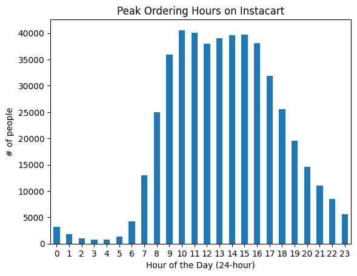

```python
#Make a bar plot:
#Title: Peak ordering hours on Instacart
#X-axis labeled "Hour of the Day (24-hour)"
#Y-axis labeled "# of people"
#order_hour_of_day should be on the x-axis
#The unique value should be on the y-axis
#kind= bar
#rotate the x-axis to 0 degrees


series_number_to_order_hour_of_day.plot(
    title="Peak Ordering Hours on Instacart",
    xlabel = "Hour of the Day (24-hour)",
    ylabel = "# of people",
    kind='bar',
    rot=0)

plt.show()
```

Most orders occur between 9:00 AM and 5:00 PM, with peaks at 10:00 AM and 3:00 PM

### What day of the week do people shop for groceries?

To figure out what day of the week people shop for groceries, analyze the order_dow column in the orders dataset. Use .value_counts() to count the number of orders for each day of the week, and then sort the results by the day index to maintain the correct order.

Visualize the data with a bar plot to clearly observe shopping patterns across the days of the week.

```python
#Create a Series from 'order_dow' using .value_counts() and organize the list in chrononlogical order using sort_index()
series_order_dow = orders['order_dow'].value_counts().sort_index()
display(series_order_dow)
```

```
0    84090
1    82185
2    65833
3    60897
4    59810
5    63488
6    62649
Name: order_dow, dtype: int64
```

```python
#Change the index names to the day of the week; this assumes Sunday = 0
series_order_dow.index = ['Sunday', 'Monday', 'Tuesday', 'Wednesday', 'Thursday', 'Friday', 'Saturday']

display(series_order_dow)
```

```
Sunday       84090
Monday       82185
Tuesday      65833
Wednesday    60897
Thursday     59810
Friday       63488
Saturday     62649
Name: order_dow, dtype: int64
```

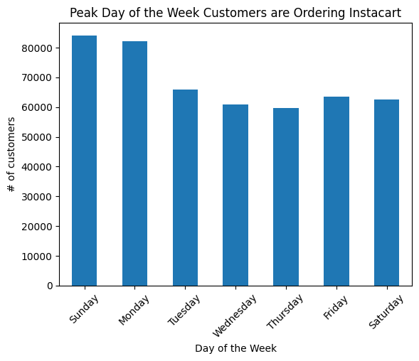

```python
#We are keeping the assumption that 0 = Sunday until otherwise stated; make a bar plot:
#Title = "Peak Day of the Week Customers are Ordering Instacart"
#xlabel = Day of the Week
#ylablel = # of customers
#kind = bar

series_order_dow.plot(title="Peak Day of the Week Customers are Ordering Instacart",
                     xlabel= "Day of the Week",
                     ylabel = "# of customers",
                     kind= 'bar',
                     rot=45)
plt.show()
```

The data dictionary does not state which integer corresponds to which day of the week. Assuming Sunday = 0, then people place more orders at the beginning of the week (Sunday and Monday).

### How long do people wait until placing another order?

To understand how long people wait before placing another order, analyze the days_since_prior_order column in the orders dataset. Use .value_counts() to count how many orders were placed for each interval of days, then sort the results by the number of days for clarity.

Visualize the data using a bar plot to observe patterns in ordering frequency over time.

```python
#Create a series using the days_since_prior_order by calling .value_counts() and put the number of days in order using .sort_index()
series_days_since_prior_order = orders['days_since_prior_order'].value_counts().sort_index()

series_days_since_prior_order.index = [0,1,2,3,4,5,6,7,8,9,10,11,12,13,14,15,16,17,18,19,20,21,22,23,24,25,26,27,28,29,30]

display(series_days_since_prior_order)
```

```
0      9589
1     20179
2     27138
3     30224
4     31006
5     30096
6     33930
7     44577
8     25361
9     16753
10    13309
11    11467
12    10658
13    11737
14    13992
```

[output cut: 17 more lines]

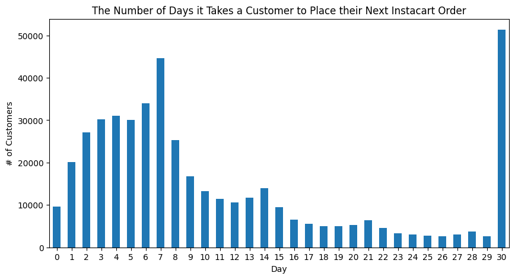

```python
#Make a bar plot:
#Title = "The Number of Days it Takes a Customer to Place their Next Instacart Order"
#Xlabel = "Days"
#ylabel = "# of Customers"
#kind = 'bar'
#rot = 0
#figsize= 10, 5

series_days_since_prior_order.plot(title= "The Number of Days it Takes a Customer to Place their Next Instacart Order",
                                  xlabel = "Day",
                                  ylabel = "# of Customers",
                                  kind= 'bar',
                                  rot= 0,
                                  figsize=[10,5]
                                  )

plt.show()
```

The 0 values probably correspond to customers who placed more than one order on the same day.

The max value of 30 days and the high spike at that value is puzzling though. The spike might be explained by people who set up recurring subscriptions to automatically order once a month. But that doesn't explain why there are no values above 30 days. I would expect many customers to place orders less often than once a month. Maybe those customers were intentionally excluded from the dataset.

Disregarding the spike at 30 days, most people wait between 2 to 10 days in between orders. The most common wait time is 7 days. In other words, it's common for people to place weekly grocery orders. Interestingly, in the tail of the distribution we also see small spikes at 14, 21, and 28 days. These would correspond to orders every 2, 3, or 4 weeks.

### Is there a difference in `'order_hour_of_day'` distributions on Wednesdays and Saturdays? Plot the histograms for both days and describe the differences that you see.

To determine if there’s a difference in the `order_hour_of_day` distributions on Wednesdays and Saturdays, follow these steps:

1. **Create masks** for Wednesday (`order_dow == 3`) and Saturday (`order_dow == 6`) to filter the orders data.
2. **Count the order hours** for each day using `.value_counts()` and sort them by hour with `.sort_index()` for clarity.
3. **Combine the counts** for both days into a single DataFrame using `pd.concat()`, and label the columns for easier interpretation.

After preparing the data, plot histograms for both days to visually compare the distribution of order times. Look for patterns such as peaks or differences in the busiest times.

```python
#Create masks for Wednesday (order_dow == 3) and Saturday (order_dow == 6)
order_dow3 = orders[orders['order_dow'] == 3]
display(order_dow3)

order_dow6 = orders[orders['order_dow']== 6]
display(order_dow6)
```

|  | order_id | user_id | order_number | order_dow | order_hour_of_day | days_since_prior_order |
| --- | --- | --- | --- | --- | --- | --- |
| 6 | 2511640 | 148233 | 40 | 3 | 8 | 2.0 |
| 16 | 3109465 | 55090 | 19 | 3 | 15 | 9.0 |
| 28 | 133707 | 182261 | 1 | 3 | 10 | NaN |
| 30 | 1890318 | 193501 | 3 | 3 | 15 | 30.0 |
| 35 | 125325 | 106853 | 6 | 3 | 19 | 30.0 |
| ... | ... | ... | ... | ... | ... | ... |
| 478902 | 972799 | 89702 | 4 | 3 | 7 | 10.0 |
| 478931 | 2406747 | 63101 | 11 | 3 | 8 | 5.0 |
| 478941 | 640934 | 27104 | 9 | 3 | 10 | 6.0 |
| 478948 | 3270802 | 112087 | 2 | 3 | 13 | 6.0 |
| 478950 | 216274 | 4391 | 3 | 3 | 8 | 8.0 |

60897 rows × 6 columns

|  | order_id | user_id | order_number | order_dow | order_hour_of_day | days_since_prior_order |
| --- | --- | --- | --- | --- | --- | --- |
| 0 | 1515936 | 183418 | 11 | 6 | 13 | 30.0 |
| 11 | 102585 | 191558 | 18 | 6 | 16 | 8.0 |
| 14 | 2843219 | 74699 | 4 | 6 | 11 | 30.0 |
| 20 | 50934 | 178510 | 9 | 6 | 9 | 5.0 |
| 26 | 1844247 | 122558 | 4 | 6 | 18 | 30.0 |
| ... | ... | ... | ... | ... | ... | ... |
| 478909 | 3274344 | 145367 | 13 | 6 | 10 | 13.0 |
| 478915 | 489820 | 7287 | 14 | 6 | 19 | 2.0 |
| 478928 | 548902 | 6829 | 3 | 6 | 10 | 30.0 |
| 478939 | 984024 | 47076 | 2 | 6 | 21 | 6.0 |
| 478946 | 3006133 | 34561 | 7 | 6 | 10 | 30.0 |

62649 rows × 6 columns

```python
#Count the order hours for each day using .value_counts() and sort them by hour with .sort_index() for clarity
series_order_hour_of_day3 = order_dow3['order_hour_of_day'].value_counts().sort_index()
display(series_order_hour_of_day3)

series_order_hour_of_day6 = order_dow6['order_hour_of_day'].value_counts().sort_index()
display(series_order_hour_of_day6)
```

```
0      373
1      215
2      106
3      101
4      108
5      170
6      643
7     1732
8     3125
9     4490
10    5026
11    5004
12    4688
13    4674
14    4774
15    5163
16    4976
17    4175
18    3463
19    2652
20    1917
21    1450
22    1154
23     718
Name: order_hour_of_day, dtype: int64
```

```
0      464
1      254
2      177
3      125
4      118
5      161
6      451
7     1619
8     3246
9     4311
10    4919
11    5116
12    5132
13    5323
14    5375
15    5188
16    5029
17    4295
18    3338
19    2610
20    1847
21    1473
22    1185
23     893
Name: order_hour_of_day, dtype: int64
```

```python
#Combine the counts for both days into a single DataFrame using pd.concat(), and label the columns for easier interpretation

wed_sat_order_hour_df = pd.concat([series_order_hour_of_day3,series_order_hour_of_day6],axis= 'columns')
wed_sat_order_hour_df.columns = ['wednesday', 'saturday']

display(wed_sat_order_hour_df)
```

|  | wednesday | saturday |
| --- | --- | --- |
| 0 | 373 | 464 |
| 1 | 215 | 254 |
| 2 | 106 | 177 |
| 3 | 101 | 125 |
| 4 | 108 | 118 |
| 5 | 170 | 161 |
| 6 | 643 | 451 |
| 7 | 1732 | 1619 |
| 8 | 3125 | 3246 |
| 9 | 4490 | 4311 |
| 10 | 5026 | 4919 |
| 11 | 5004 | 5116 |
| 12 | 4688 | 5132 |
| 13 | 4674 | 5323 |
| 14 | 4774 | 5375 |
| 15 | 5163 | 5188 |
| 16 | 4976 | 5029 |
| 17 | 4175 | 4295 |
| 18 | 3463 | 3338 |
| 19 | 2652 | 2610 |
| 20 | 1917 | 1847 |
| 21 | 1450 | 1473 |
| 22 | 1154 | 1185 |
| 23 | 718 | 893 |

[figure not shown]

```python
#plot histograms for both days to visually compare the distribution of order times. Look for patterns such as peaks or differences in the busiest times.
order_dow3['order_hour_of_day'].plot(kind='hist', title = "Order Hour of the Day")
order_dow6['order_hour_of_day'].plot(kind='hist', alpha=0.8, grid=True)

plt.legend(['Wednesday','Thursday'])
plt.show()
```

There's a small dip from 11h to 13h on Wednesdays. This dip is absent on Saturdays. Maybe this dip can be attributed to people who don't use Instacart because they have lunch somewhere between 11h and 13h.

### What's the distribution for the number of orders per customer?

To explore the distribution of the number of orders per customer:

1. **Group the data** by `user_id` to calculate the total number of orders for each customer. Use `.groupby('user_id')` and count the `order_id` for each group.
2. **Sort the results** using `.sort_values()` for better readability.
3. **Visualize the distribution** using a histogram to observe how many orders most customers typically place.

Adjust the number of bins in the histogram to refine the visualization and better capture the pattern.

```python
display(orders.head())

#Group the data by user_id and order_id using .groupby() and sort by using .sort_values() for better readability
orders_per_customer = orders.groupby('user_id')['order_id'].count().sort_values()
display(orders_per_customer)
```

|  | order_id | user_id | order_number | order_dow | order_hour_of_day | days_since_prior_order |
| --- | --- | --- | --- | --- | --- | --- |
| 0 | 1515936 | 183418 | 11 | 6 | 13 | 30.0 |
| 1 | 1690866 | 163593 | 5 | 5 | 12 | 9.0 |
| 2 | 1454967 | 39980 | 4 | 5 | 19 | 2.0 |
| 3 | 1768857 | 82516 | 56 | 0 | 20 | 10.0 |
| 4 | 3007858 | 196724 | 2 | 4 | 12 | 17.0 |

```
user_id
152331     1
139876     1
60408      1
139873     1
139871     1
          ..
66664     24
148162    24
78375     25
193164    26
149605    28
Name: order_id, Length: 157437, dtype: int64
```

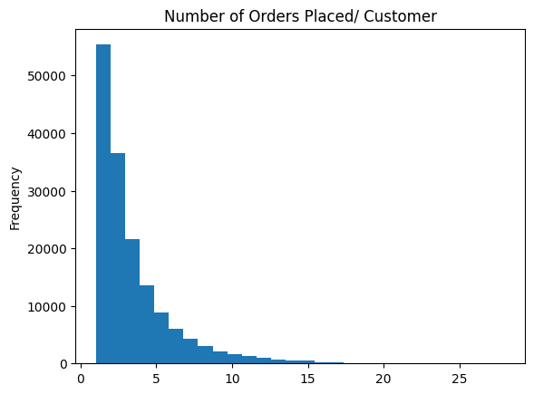

```python
#Use a histogram to observe how many orders most customers place; adjust the bins as necessary
orders_per_customer.plot(kind='hist',title = "Number of Orders Placed/ Customer", bins=28)
```

Most customers in the dataset have placed between 1 and 10 orders, with number of orders per customer sharply decreasing after just 1 order.

### What are the top 20 popular products (display their id and name)?

To identify the top 20 most popular products:

1. **Merge the datasets**: Combine `order_products` and `products` on `product_id` to access both the product IDs and names in a single DataFrame.
2. **Group the data**: Group by both `product_id` and `product_name` to aggregate the order counts for each product using `.size()`.
3. **Sort the results**: Use `.sort_values(ascending=False)` to rank products by their popularity.
4. **Display the top 20**: Use `.head(20)` to focus on the most frequently ordered products.
5. **Visualize the results**: Create a bar chart to highlight the top products and their order counts.

This will give you a clear view of the most popular products and their ranking.

```python
#Merge the datasets: Combine order_products and products DF using product_id to access product ID and name in one DF
product_id_df = order_products.merge(products, on='product_id')


display(product_id_df)
```

|  | order_id | product_id | add_to_cart_order | reordered | missing_add_to_cart_order | product_name | aisle_id | department_id |
| --- | --- | --- | --- | --- | --- | --- | --- | --- |
| 0 | 2141543 | 11440 | 17 | 0 | False | ultra thin pizza crust | 129 | 1 |
| 1 | 147172 | 11440 | 7 | 1 | False | ultra thin pizza crust | 129 | 1 |
| 2 | 3341719 | 11440 | 4 | 1 | False | ultra thin pizza crust | 129 | 1 |
| 3 | 1938779 | 11440 | 8 | 1 | False | ultra thin pizza crust | 129 | 1 |
| 4 | 1728338 | 11440 | 23 | 0 | False | ultra thin pizza crust | 129 | 1 |
| ... | ... | ... | ... | ... | ... | ... | ... | ... |
| 4545002 | 267402 | 45226 | 14 | 0 | False | sore throat plus coating protection wild berry... | 5 | 13 |
| 4545003 | 2621676 | 25201 | 10 | 0 | False | salted caramel & chocolate non dairy frozen de... | 101 | 17 |
| 4545004 | 937623 | 49153 | 2 | 0 | False | NaN | 22 | 11 |
| 4545005 | 532895 | 8182 | 1 | 0 | False | 34% cacao milk chocolate bar | 20 | 11 |
| 4545006 | 3132243 | 40024 | 1 | 0 | False | superfood cereal maca double chocolate | 17 | 13 |

4545007 rows × 8 columns

```python
#Group the data by product_id and product_name to aggregate the order counts for each product using .size() and use .sort_values()
product_name_id_size = product_id_df.groupby(['product_name','product_id']).size().sort_values(ascending=False)

top20_product = product_name_id_size.head(20)
display(top20_product)
```

```
product_name                                      product_id
boomchickapop sea salt popcorn                    24852         66050
gluten free plain tortilla                        13176         53297
cookies- family recipe- double chocolate chip     21137         37039
gingerbread spice 45% milk chocolate              21903         33971
avocado                                           47209         29773
classic with tuna anchovies & whitefish cat food  47766         24689
peach bbq sauce                                   47626         21495
organix grain free shredded chicken cat food      16797         20018
wild caught boiled baby clams                     26209         19690
chicken breast cutlets                            27845         19600
seasoned italian style bread crumbs               27966         19197
light brown sugar                                 22935         15898
strawberry vanilla marshmallows                   24964         15292
hickory smoked boneless sliced ham                45007         14584
maple greek yogurt                                39275         13879
smoked turkey                                     28204         12544
organic sun dried dates                           5876          12232
lucky charms marshmallow flavor treats            8277          11993
solid white albacore                              40706         11781
walnut oil                                        4920          11755
dtype: int64
```

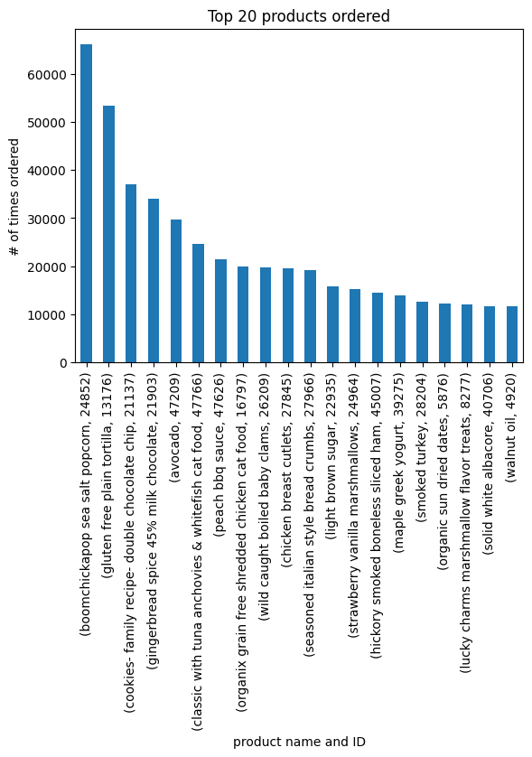

```python
#Create a bar chart to highlight the top products and their order counts.
top20_product.plot(x='product_name',
                   kind='bar',
                   xlabel = "product name and ID",
                   ylabel= "# of times ordered",
                   title="Top 20 products ordered")

plt.show()
```

### How many items do people typically buy in one order? What does the distribution look like?

To analyze how many items people typically buy in one order:

1. **Group the data** by `order_id` and count the number of products (`product_id`) in each order using `.count()`. This gives the number of items in each order.
2. **Aggregate the counts**: Use `.value_counts()` to determine how frequently different order sizes occur, and then sort the results with `.sort_index()` to organize by the number of items.
3. **Visualize the distribution**: Use a bar plot to show the frequency of orders for each size, with the x-axis representing the number of items and the y-axis representing the number of orders.

This will help you understand the typical size of a grocery order and identify any trends in purchasing behavior.

```python
display(order_products.head())

#Group the data in the order_products dataset by order_id and count the # of product_id using .count()
order_products_series = order_products.groupby('order_id')['product_id'].count().sort_values(ascending=True)
display(order_products_series)
```

|  | order_id | product_id | add_to_cart_order | reordered | missing_add_to_cart_order |
| --- | --- | --- | --- | --- | --- |
| 0 | 2141543 | 11440 | 17 | 0 | False |
| 1 | 567889 | 1560 | 1 | 1 | False |
| 2 | 2261212 | 26683 | 1 | 1 | False |
| 3 | 491251 | 8670 | 35 | 1 | False |
| 4 | 2571142 | 1940 | 5 | 1 | False |

```
order_id
3421079      1
1288686      1
1288764      1
1288825      1
1288873      1
          ...
1959075     98
171934     104
2136777    108
3308010    115
61355      127
Name: product_id, Length: 450046, dtype: int64
```

```python
# Use .value_counts() to determine how frequently different order sizes occur, and then sort the results with .sort_index() to organize by the number of items.
order_products_value_sort_index = order_products_series.value_counts().sort_index()
display(order_products_value_sort_index.head(35))

order_products_35 = pd.Series(order_products_value_sort_index,index=
                              [1, 2, 3, 4, 5, 6, 7, 8, 9, 10, 11, 12, 13, 14, 15, 16, 17, 18, 19, 20, 21, 22, 23, 24, 25, 26, 27, 28, 29, 30, 31, 32, 33, 34, 35])

display(order_products_35)
```

```
1     21847
2     26292
3     29046
4     31054
5     31923
6     31698
7     30822
8     28539
9     25742
10    23248
11    20406
12    18539
13    16497
14    14472
15    12696
```

[output cut: 21 more lines]

```
1     21847
2     26292
3     29046
4     31054
5     31923
6     31698
7     30822
8     28539
9     25742
10    23248
11    20406
12    18539
13    16497
14    14472
15    12696
```

[output cut: 21 more lines]

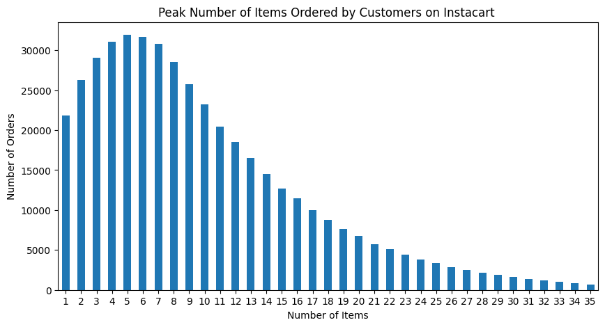

```python
# Use bar plot to show the frequency of orders for each size,
#x-axis representing the number of items
#y-axis representing the number of orders.



order_products_35.plot(kind='bar',
                                    title = "Peak Number of Items Ordered by Customers on Instacart ",
                                    xlabel = "Number of Items",
                                    ylabel = "Number of Orders",
                                    rot=0,
                                    figsize= [10,5])

plt.show()
```

The typical order contains 5 or 6 items, with most orders having between 1 and 20 items.

### What are the top 20 items that are reordered most frequently (display their names and product IDs)?

To find the top 20 most frequently reordered items:

1. **Filter the data**: Use `order_products['reordered'] == 1` to isolate only the products that have been reordered.
2. **Merge the datasets**: Combine the filtered `order_products` with the `products` dataset on `product_id` to get both the product names and IDs.
3. **Group the data**: Group by both `product_id` and `product_name` to calculate how many times each product was reordered, using `.size()`.
4. **Sort the results**: Use `.sort_values(ascending=False)` to rank the products by reorder frequency.
5. **Display the top 20**: Use `.head(20)` to focus on the most frequently reordered products.
6. **Visualize the data**: Create a bar chart to showcase the top reordered items and their frequencies.

This process highlights the products that customers consistently return to and reorder.

```python
#Filter data: Use order_products['reordered'] == 1 to isolate only the products that have been reordered.
reordered1_df = order_products[order_products['reordered'] == 1]
display(reordered1_df)
```

|  | order_id | product_id | add_to_cart_order | reordered | missing_add_to_cart_order |
| --- | --- | --- | --- | --- | --- |
| 1 | 567889 | 1560 | 1 | 1 | False |
| 2 | 2261212 | 26683 | 1 | 1 | False |
| 3 | 491251 | 8670 | 35 | 1 | False |
| 4 | 2571142 | 1940 | 5 | 1 | False |
| 5 | 2456893 | 21616 | 4 | 1 | False |
| ... | ... | ... | ... | ... | ... |
| 4544999 | 1622300 | 24852 | 1 | 1 | False |
| 4545000 | 1125324 | 40600 | 6 | 1 | False |
| 4545002 | 577211 | 15290 | 12 | 1 | False |
| 4545004 | 692640 | 47766 | 4 | 1 | False |
| 4545005 | 319435 | 691 | 8 | 1 | False |

2683838 rows × 5 columns

```python
#Merge the datasets: Combine the filtered order_products reordered1_df with the
#products dataset on product_id to get both the product names and IDs.
order_products_reorder_df = reordered1_df.merge(products,on='product_id')
display(order_products_reorder_df)
```

|  | order_id | product_id | add_to_cart_order | reordered | missing_add_to_cart_order | product_name | aisle_id | department_id |
| --- | --- | --- | --- | --- | --- | --- | --- | --- |
| 0 | 567889 | 1560 | 1 | 1 | False | organic poultry seasoning | 37 | 1 |
| 1 | 761899 | 1560 | 2 | 1 | False | organic poultry seasoning | 37 | 1 |
| 2 | 1388514 | 1560 | 8 | 1 | False | organic poultry seasoning | 37 | 1 |
| 3 | 2629631 | 1560 | 1 | 1 | False | organic poultry seasoning | 37 | 1 |
| 4 | 866921 | 1560 | 6 | 1 | False | organic poultry seasoning | 37 | 1 |
| ... | ... | ... | ... | ... | ... | ... | ... | ... |
| 2683833 | 1338379 | 33506 | 3 | 1 | False | real ice cream salted caramel | 40 | 8 |
| 2683834 | 191894 | 27878 | 3 | 1 | False | burgers- veggie- black bean south west | 78 | 19 |
| 2683835 | 3041739 | 31751 | 14 | 1 | False | thin to thick extra volume conditioner | 116 | 1 |
| 2683836 | 949244 | 24384 | 18 | 1 | False | organic super fruit energy drink | 10 | 17 |
| 2683837 | 1078099 | 47673 | 11 | 1 | False | beyond natural cat food - white meat chicken a... | 78 | 19 |

2683838 rows × 8 columns

```python
#Group the data: Group by both product_id and product_name to calculate how many times each product was reordered, using .size().
#Sort the results: Use .sort_values(ascending=False) to rank the products by reorder frequency.
order_products_reorder_series = order_products_reorder_df.groupby(['product_id','product_name']).size().sort_values(ascending=False)

#Display the top 20: Use .head(20) to focus on the most frequently reordered products.
order_products_reorder_series = order_products_reorder_series.head(20)
display(order_products_reorder_series)
```

```
product_id  product_name
24852       boomchickapop sea salt popcorn                      55763
13176       gluten free plain tortilla                          44450
21137       cookies- family recipe- double chocolate chip       28639
21903       gingerbread spice 45% milk chocolate                26233
47209       avocado                                             23629
47766       classic with tuna anchovies & whitefish cat food    18743
27845       chicken breast cutlets                              16251
47626       peach bbq sauce                                     15044
27966       seasoned italian style bread crumbs                 14748
16797       organix grain free shredded chicken cat food        13945
26209       wild caught boiled baby clams                       13327
22935       light brown sugar                                   11145
24964       strawberry vanilla marshmallows                     10411
45007       hickory smoked boneless sliced ham                  10076
28204       smoked turkey                                        8989
8277        lucky charms marshmallow flavor treats               8836
39275       maple greek yogurt                                   8799
5876        organic sun dried dates                              8412
44632       little champions variety pack                        8187
19057       organix grain free chicken & vegetable dog food      8106
dtype: int64
```

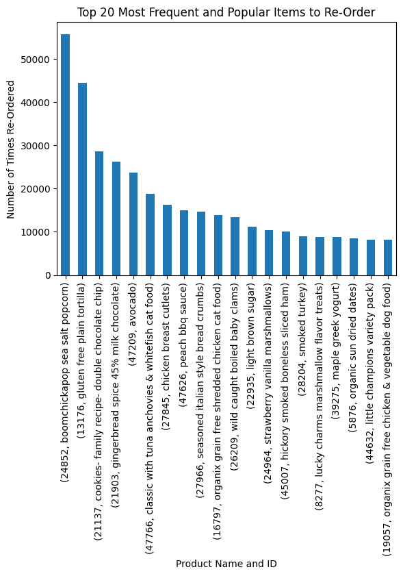

```python
#Visualize the data: Create a bar chart to showcase the top reordered items and their frequencies.
order_products_reorder_series.plot(kind='bar',
                                   title= "Top 20 Most Frequent and Popular Items to Re-Order",
                                  ylabel= "Number of Times Re-Ordered",
                                  xlabel= "Product Name and ID")

plt.show()
```

### For each product, what proportion of its orders are reorders?

To calculate the proportion of orders for each product that are reorders:

1. **Merge the datasets**: Combine `order_products` with the `products` dataset to access product names and IDs in the same DataFrame.
2. **Group the data**: Group by `product_id` and `product_name` to isolate each product's order history.
3. **Calculate the mean of `reordered`**: Use `.mean()` on the `reordered` column to compute the proportion of orders for each product that were reorders. The value represents the reorder rate.
4. **Sort the results**: Use `.sort_values(ascending=False)` to rank products by their reorder rates.
5. **Convert to a DataFrame**: Use `.reset_index()` to organize the grouped data into a readable DataFrame.
6. **Optional Sorting**: Sort the results by `product_id` or another column for better clarity.

This approach provides insights into how frequently each product is reordered, helping identify customer favorites or staples.

```python
#Merge the datasets: Combine order_products with the products dataset to access product names and IDs in the same DataFrame.
order_products_merged = order_products.merge(products,on='product_id')
display(order_products_merged)
```

|  | order_id | product_id | add_to_cart_order | reordered | missing_add_to_cart_order | product_name | aisle_id | department_id |
| --- | --- | --- | --- | --- | --- | --- | --- | --- |
| 0 | 2141543 | 11440 | 17 | 0 | False | ultra thin pizza crust | 129 | 1 |
| 1 | 147172 | 11440 | 7 | 1 | False | ultra thin pizza crust | 129 | 1 |
| 2 | 3341719 | 11440 | 4 | 1 | False | ultra thin pizza crust | 129 | 1 |
| 3 | 1938779 | 11440 | 8 | 1 | False | ultra thin pizza crust | 129 | 1 |
| 4 | 1728338 | 11440 | 23 | 0 | False | ultra thin pizza crust | 129 | 1 |
| ... | ... | ... | ... | ... | ... | ... | ... | ... |
| 4545002 | 267402 | 45226 | 14 | 0 | False | sore throat plus coating protection wild berry... | 5 | 13 |
| 4545003 | 2621676 | 25201 | 10 | 0 | False | salted caramel & chocolate non dairy frozen de... | 101 | 17 |
| 4545004 | 937623 | 49153 | 2 | 0 | False | NaN | 22 | 11 |
| 4545005 | 532895 | 8182 | 1 | 0 | False | 34% cacao milk chocolate bar | 20 | 11 |
| 4545006 | 3132243 | 40024 | 1 | 0 | False | superfood cereal maca double chocolate | 17 | 13 |

4545007 rows × 8 columns

```python
#Group the data: Group by product_id and product_name to isolate each product's order history.
order_products_grouped = order_products_merged.groupby('product_id')['product_name'].count()
display(order_products_grouped)
```

```
product_id
1        280
2         11
3         42
4         49
7          2
        ...
49690      0
49691      0
49692      0
49693      0
49694      0
Name: product_name, Length: 45573, dtype: int64
```

```python
#Calculate the mean of reordered: Use .mean() on the reordered column to compute the proportion of orders for each product that were
#reorders. The value represents the reorder rate.
mean_reordered = order_products_merged.groupby(['product_id', 'product_name'])['reordered'].mean()
display(mean_reordered)
```

```
product_id  product_name
1           chocolate sandwich cookies                                           0.564286
2           all-seasons salt                                                     0.000000
3           robust golden unsweetened oolong tea                                 0.738095
4           smart ones classic favorites mini rigatoni with vodka cream sauce    0.510204
7           pure coconut water with orange                                       0.500000
                                                                                   ...
48329       vodka- triple distilled- twist of vanilla                            0.428571
48330       en croute roast hazelnut cranberry                                   0.000000
48331       artisan baguette                                                     1.000000
48332       smartblend healthy metabolism dry cat food                           0.526316
48333       fresh foaming cleanser                                               0.551724
Name: reordered, Length: 44312, dtype: float64
```

```python
#Sort the results: Use .sort_values(ascending=False) to rank products by their reorder rates.
sort = mean_reordered.sort_values(ascending=False)
display(sort)
```

```
product_id  product_name
25933       gravy- country-style sausage                      1.0
9335        macro bowl                                        1.0
19936       for men 3 in 1 nourishing lotion sea minerals     1.0
24452       egyptian licorice tea bags                        1.0
44918       three meat & four cheese lasagna                  1.0
                                                             ...
39797       baby rice cereal                                  0.0
10336       kickstart midnight grape                          0.0
22004       albacore solid white tuna in water                0.0
17860       foamy regular shave cream 11oz male shave prep    0.0
26501       sparkling catawba grape juice                     0.0
Name: reordered, Length: 44312, dtype: float64
```

```python
#Convert to a DataFrame: Use .reset_index() to organize the grouped data into a readable DataFrame.
reordered_df = pd.DataFrame(sort).reset_index()
display(reordered_df.head(20))
```

|  | product_id | product_name | reordered |
| --- | --- | --- | --- |
| 0 | 25933 | gravy- country-style sausage | 1.0 |
| 1 | 9335 | macro bowl | 1.0 |
| 2 | 19936 | for men 3 in 1 nourishing lotion sea minerals | 1.0 |
| 3 | 24452 | egyptian licorice tea bags | 1.0 |
| 4 | 44918 | three meat & four cheese lasagna | 1.0 |
| 5 | 30741 | organic pearl heirloom quinoa | 1.0 |
| 6 | 30747 | whole grain brown ready rice | 1.0 |
| 7 | 8319 | cool mint antiseptic mouthwash | 1.0 |
| 8 | 39607 | spinach artichoke dip | 1.0 |
| 9 | 30748 | chocolate deluxe bars | 1.0 |
| 10 | 19896 | chicken curry | 1.0 |
| 11 | 3367 | sensitivity ultra thin premium lubricant condoms | 1.0 |
| 12 | 42788 | whole grain garlic and pecan rice | 1.0 |
| 13 | 2655 | organic cat nip | 1.0 |
| 14 | 30653 | dairy-free cheddar style wedges | 1.0 |
| 15 | 19861 | magnesium citrate tabs | 1.0 |
| 16 | 19853 | lower sodium bacon | 1.0 |
| 17 | 44951 | red grapefruit | 1.0 |
| 18 | 27127 | organic lemon fruit spread | 1.0 |
| 19 | 6897 | 6-18 months ultra soft toothbrush | 1.0 |

```python
#Optional Sorting: Sort the results by product_id or another column for better clarity.
sort_reordered_df = reordered_df.sort_values(by='product_id')
display(sort_reordered_df)
```

|  | product_id | product_name | reordered |
| --- | --- | --- | --- |
| 11805 | 1 | chocolate sandwich cookies | 0.564286 |
| 37237 | 2 | all-seasons salt | 0.000000 |
| 3726 | 3 | robust golden unsweetened oolong tea | 0.738095 |
| 14557 | 4 | smart ones classic favorites mini rigatoni wit... | 0.510204 |
| 15770 | 7 | pure coconut water with orange | 0.500000 |
| ... | ... | ... | ... |
| 21289 | 48329 | vodka- triple distilled- twist of vanilla | 0.428571 |
| 37326 | 48330 | en croute roast hazelnut cranberry | 0.000000 |
| 1196 | 48331 | artisan baguette | 1.000000 |
| 13940 | 48332 | smartblend healthy metabolism dry cat food | 0.526316 |
| 12533 | 48333 | fresh foaming cleanser | 0.551724 |

44312 rows × 3 columns

For each product, what proportion of its orders are reorders? The answer lies in the `reordered` column. If you want to know the percent of times that a product is ordered, you would find the product, look at the `reordered` column, and times that decimal by 100. For example: "chocolate sandwich cookies" are reordered 56.43% of the time (this value is rounded up).

### For each customer, what proportion of their products ordered are reorders?

To calculate the proportion of products reordered by each customer:

1. **Merge the datasets**: Combine `order_products` with `orders` to link order and customer information.
2. **Group the data**: Group by `user_id` to focus on each customer's ordering behavior.
3. **Calculate the mean of `reordered`**: Use `.mean()` on the `reordered` column to determine the proportion of products reordered by each customer.
4. **Sort the results**: Use `.sort_values(ascending=False)` to identify customers with the highest reorder rates.
5. **Convert to a DataFrame**: Use `.reset_index()` to format the grouped data into a structured DataFrame for further analysis.

This analysis reveals the extent to which individual customers reorder products, providing insights into customer loyalty and preferences.

```python
#Merge order_products with orders to link order_id and user_id
orders_merged_df = orders.merge(order_products, on='order_id')
display(orders_merged_df)
```

|  | order_id | user_id | order_number | order_dow | order_hour_of_day | days_since_prior_order | product_id | add_to_cart_order | reordered | missing_add_to_cart_order |
| --- | --- | --- | --- | --- | --- | --- | --- | --- | --- | --- |
| 0 | 1515936 | 183418 | 11 | 6 | 13 | 30.0 | 19048 | 1 | 1 | False |
| 1 | 1515936 | 183418 | 11 | 6 | 13 | 30.0 | 47766 | 3 | 1 | False |
| 2 | 1515936 | 183418 | 11 | 6 | 13 | 30.0 | 45066 | 9 | 0 | False |
| 3 | 1515936 | 183418 | 11 | 6 | 13 | 30.0 | 24082 | 11 | 0 | False |
| 4 | 1515936 | 183418 | 11 | 6 | 13 | 30.0 | 24363 | 4 | 0 | False |
| ... | ... | ... | ... | ... | ... | ... | ... | ... | ... | ... |
| 4545002 | 2071924 | 1730 | 18 | 1 | 14 | 15.0 | 1503 | 17 | 0 | False |
| 4545003 | 2071924 | 1730 | 18 | 1 | 14 | 15.0 | 4778 | 12 | 1 | False |
| 4545004 | 2071924 | 1730 | 18 | 1 | 14 | 15.0 | 11512 | 1 | 1 | False |
| 4545005 | 2071924 | 1730 | 18 | 1 | 14 | 15.0 | 4920 | 6 | 1 | False |
| 4545006 | 2071924 | 1730 | 18 | 1 | 14 | 15.0 | 17678 | 4 | 1 | False |

4545007 rows × 10 columns

```python
#Group by user_id to focus on each customer's ordering behavior
orders_grouped_df = orders_merged_df.groupby(['user_id','product_id'])['reordered'].size()
display(orders_grouped_df)
```

```
user_id  product_id
2        9681          1
         12000         1
         13176         1
         16589         1
         20574         1
                      ..
206209   39216         1
         40992         1
         41213         1
         41665         1
         43961         1
Name: reordered, Length: 3381866, dtype: int64
```

```python
#Calculate the mean of reordered: use .mean() on the reordered column to determine the proportion of products reordered by each customer
proportion_reordered_products = orders_merged_df.groupby('user_id')['reordered'].mean()
display(proportion_reordered_products)
```

```
user_id
2         0.038462
4         0.000000
5         0.666667
6         0.000000
7         0.928571
            ...
206203    0.222222
206206    0.714286
206207    0.891304
206208    0.696000
206209    0.320000
Name: reordered, Length: 149626, dtype: float64
```

```python
#Use .sort_values(ascending=False) to ID customers with the highest reorder rates
customer_reorder_rate = proportion_reordered_products.sort_values(ascending=False)
display(customer_reorder_rate)
```

```
user_id
137587    1.0
173474    1.0
13918     1.0
62300     1.0
62307     1.0
         ...
190953    0.0
119371    0.0
63173     0.0
63163     0.0
165726    0.0
Name: reordered, Length: 149626, dtype: float64
```

```python
#Convert to a DataFrame: Use .reset_index() to format the grouped data into a structured DataFrame for further analysis.
customer_reorder_rate_df = customer_reorder_rate.reset_index()
display(customer_reorder_rate_df)
```

|  | user_id | reordered |
| --- | --- | --- |
| 0 | 137587 | 1.0 |
| 1 | 173474 | 1.0 |
| 2 | 13918 | 1.0 |
| 3 | 62300 | 1.0 |
| 4 | 62307 | 1.0 |
| ... | ... | ... |
| 149621 | 190953 | 0.0 |
| 149622 | 119371 | 0.0 |
| 149623 | 63173 | 0.0 |
| 149624 | 63163 | 0.0 |
| 149625 | 165726 | 0.0 |

149626 rows × 2 columns

### What are the top 20 items that people put in their carts first?

To identify the top 20 items that people most frequently add to their carts first:

1. **Merge the datasets**: Combine `order_products` with `products` to link product names and IDs.
2. **Filter the data**: Focus on rows where `add_to_cart_order` equals 1, indicating the first item added to the cart.
3. **Group the data**: Group by `product_id` and `product_name` to aggregate the count of how often each product was the first in a cart.
4. **Count occurrences**: Use `.count()` to calculate the total number of times each product was the first added.
5. **Sort the results**: Use `.sort_values(ascending=False)` to rank products by their first-in-cart frequency.
6. **Display the top 20**: Use `.head(20)` to extract the most popular first-in-cart items.

This provides insights into which products customers prioritize in their shopping process.

```python
#Merge the datasets: Combine order_products with products to link product names and IDs.
top20_cart_df = order_products.merge(products,on='product_id')
display(top20_cart_df)
```

|  | order_id | product_id | add_to_cart_order | reordered | missing_add_to_cart_order | product_name | aisle_id | department_id |
| --- | --- | --- | --- | --- | --- | --- | --- | --- |
| 0 | 2141543 | 11440 | 17 | 0 | False | ultra thin pizza crust | 129 | 1 |
| 1 | 147172 | 11440 | 7 | 1 | False | ultra thin pizza crust | 129 | 1 |
| 2 | 3341719 | 11440 | 4 | 1 | False | ultra thin pizza crust | 129 | 1 |
| 3 | 1938779 | 11440 | 8 | 1 | False | ultra thin pizza crust | 129 | 1 |
| 4 | 1728338 | 11440 | 23 | 0 | False | ultra thin pizza crust | 129 | 1 |
| ... | ... | ... | ... | ... | ... | ... | ... | ... |
| 4545002 | 267402 | 45226 | 14 | 0 | False | sore throat plus coating protection wild berry... | 5 | 13 |
| 4545003 | 2621676 | 25201 | 10 | 0 | False | salted caramel & chocolate non dairy frozen de... | 101 | 17 |
| 4545004 | 937623 | 49153 | 2 | 0 | False | NaN | 22 | 11 |
| 4545005 | 532895 | 8182 | 1 | 0 | False | 34% cacao milk chocolate bar | 20 | 11 |
| 4545006 | 3132243 | 40024 | 1 | 0 | False | superfood cereal maca double chocolate | 17 | 13 |

4545007 rows × 8 columns

```python
#Filter the data: Focus on rows where add_to_cart_order equals 1, indicating the first item added to the cart.
top20_cart_df = top20_cart_df[top20_cart_df['add_to_cart_order'] == 1]
display(top20_cart_df)
```

|  | order_id | product_id | add_to_cart_order | reordered | missing_add_to_cart_order | product_name | aisle_id | department_id |
| --- | --- | --- | --- | --- | --- | --- | --- | --- |
| 6 | 1463503 | 11440 | 1 | 0 | False | ultra thin pizza crust | 129 | 1 |
| 17 | 2201430 | 11440 | 1 | 1 | False | ultra thin pizza crust | 129 | 1 |
| 21 | 1036054 | 11440 | 1 | 1 | False | ultra thin pizza crust | 129 | 1 |
| 50 | 3008652 | 11440 | 1 | 1 | False | ultra thin pizza crust | 129 | 1 |
| 62 | 2946144 | 11440 | 1 | 1 | False | ultra thin pizza crust | 129 | 1 |
| ... | ... | ... | ... | ... | ... | ... | ... | ... |
| 4544972 | 1518168 | 16952 | 1 | 0 | False | short macaroni pasta | 73 | 11 |
| 4544977 | 1776450 | 21507 | 1 | 0 | False | silicone baby 3-12 months toothbrush | 17 | 13 |
| 4544995 | 2333206 | 25467 | 1 | 0 | False | organic lavender hand sanitizer | 17 | 13 |
| 4545005 | 532895 | 8182 | 1 | 0 | False | 34% cacao milk chocolate bar | 20 | 11 |
| 4545006 | 3132243 | 40024 | 1 | 0 | False | superfood cereal maca double chocolate | 17 | 13 |

450046 rows × 8 columns

```python
#Group the data: Group by product_id and product_name to aggregate the count of how often each product was the first in a cart.
top20_cart_group = top20_cart_df.groupby(['product_id','product_name']).size()
display(top20_cart_group)
```

```
product_id  product_name
1           chocolate sandwich cookies                                           47
2           all-seasons salt                                                      2
3           robust golden unsweetened oolong tea                                  5
4           smart ones classic favorites mini rigatoni with vodka cream sauce     1
8           cut russet potatoes steam n' mash                                     4
                                                                                 ..
48328       cucumber kirby                                                        2
48329       vodka- triple distilled- twist of vanilla                             2
48331       artisan baguette                                                      1
48332       smartblend healthy metabolism dry cat food                            1
48333       fresh foaming cleanser                                                2
Length: 26050, dtype: int64
```

```python
#Count occurrences: Use .count() to calculate the total number of times each product was the first added.
top20_cart_group_count = top20_cart_df.groupby(['product_id','product_name'])['add_to_cart_order'].count()
display(top20_cart_group_count)
```

```
product_id  product_name
1           chocolate sandwich cookies                                           47
2           all-seasons salt                                                      2
3           robust golden unsweetened oolong tea                                  5
4           smart ones classic favorites mini rigatoni with vodka cream sauce     1
8           cut russet potatoes steam n' mash                                     4
                                                                                 ..
48328       cucumber kirby                                                        2
48329       vodka- triple distilled- twist of vanilla                             2
48331       artisan baguette                                                      1
48332       smartblend healthy metabolism dry cat food                            1
48333       fresh foaming cleanser                                                2
Name: add_to_cart_order, Length: 26050, dtype: int64
```

```python
#Sort the results: Use .sort_values(ascending=False) to rank products by their first-in-cart frequency.
top20_cart_sort = top20_cart_group_count.sort_values(ascending=False)
display(top20_cart_sort)
```

```
product_id  product_name
24852       boomchickapop sea salt popcorn                           15562
13176       gluten free plain tortilla                               11026
27845       chicken breast cutlets                                    4363
21137       cookies- family recipe- double chocolate chip             3946
47209       avocado                                                   3390
                                                                     ...
37932       crispy thin crust spinach & artichoke pizza                  1
17011       air chilled organic boneless skinless chicken breasts        1
31330       magnum bareskin condoms                                      1
25847       with sweet cinnamon bunches cereal                           1
29087       uniquely sharp mustard                                       1
Name: add_to_cart_order, Length: 26050, dtype: int64
```

```python
#Display the top 20: Use .head(20) to extract the most popular first-in-cart items.
display(top20_cart_sort.head(20))
```

```
product_id  product_name
24852       boomchickapop sea salt popcorn                      15562
13176       gluten free plain tortilla                          11026
27845       chicken breast cutlets                               4363
21137       cookies- family recipe- double chocolate chip        3946
47209       avocado                                              3390
21903       gingerbread spice 45% milk chocolate                 3336
47766       classic with tuna anchovies & whitefish cat food     3044
19660       organic roots vegetable juice blend                  2336
16797       organix grain free shredded chicken cat food         2308
27966       seasoned italian style bread crumbs                  2024
44632       little champions variety pack                        1914
47626       peach bbq sauce                                      1737
196         tzatziki cucumber sauce                              1733
38689       blissfuls in-wash scent booster                      1397
26209       wild caught boiled baby clams                        1370
12341       ground espresso coffee medium roast                  1340
5785        deodorant- liquid rock- sport- tube                  1310
27086       gluten free cranberry almond snack bars              1309
43352       gluten free lemon streusel muffins                   1246
22935       light brown sugar                                    1246
Name: add_to_cart_order, dtype: int64
```